# Build and deploy a stroke prediction model using R

Nitin Panwar!

2024-01-23

# About Data Analysis Report

This RMarkdown file contains the report of the data analysis done for the project on building and deploying a stroke prediction model in R. It contains analysis such as data exploration, summary statistics and building the prediction models. The final report was completed on Tue Jan 23 22:20:44 2024.

**Data Description:**

According to the World Health Organization (WHO) stroke is the 2nd leading cause of death globally, responsible for approximately 11% of total deaths.

This data set is used to predict whether a patient is likely to get stroke based on the input parameters like gender, age, various diseases, and smoking status. Each row in the data provides relevant information about the patient.

# Task One: Import data and data preprocessing

## Load data and install packages

```r
#install.packages("tidyverse")
#install.packages("tidymodels")
#install.packages("ranger")
library(tidymodels)
library(tidyverse)
library(dplyr)
library(readr)
library(skimr)
filename<-"healthcare-dataset-stroke-data.csv"
dataset <- read.csv(filename,header = TRUE,na.strings=c("N/A","NA"))
dataset <- dataset %>%
  mutate_all(~ ifelse(. == "Unknown", NA, .))
str(dataset)
```

```
## 'data.frame':    5110 obs. of  12 variables:
##  $ id               : int  9046 51676 31112 60182 1665 56669 53882 10434 27419 60491 ...
##  $ gender           : chr  "Male" "Female" "Male" "Female" ...
##  $ age              : num  67 61 80 49 79 81 74 69 59 78 ...
##  $ hypertension     : int  0 0 0 0 1 0 1 0 0 0 ...
##  $ heart_disease    : int  1 0 1 0 0 0 1 0 0 0 ...
##  $ ever_married     : chr  "Yes" "Yes" "Yes" "Yes" ...
##  $ work_type        : chr  "Private" "Self-employed" "Private" "Private" ...
##  $ Residence_type   : chr  "Urban" "Rural" "Rural" "Urban" ...
##  $ avg_glucose_level: num  229 202 106 171 174 ...
##  $ bmi              : num  36.6 NA 32.5 34.4 24 29 27.4 22.8 NA 24.2 ...
##  $ smoking_status   : chr  "formerly smoked" "never smoked" "never smoked" "smokes" ...
##  $ stroke           : int  1 1 1 1 1 1 1 1 1 1 ...
```

## Describe and explore the data

```r
#dimension of dataset
dim(dataset)
```

```
## [1] 5110   12
```

```r
#summarize attribute distributions
skim(dataset)
```

Data summary

| Name | dataset |
| --- | --- |
| Number of rows | 5110 |
| Number of columns | 12 |
| _______________________ |  |
| Column type frequency: |  |
| character | 5 |
| numeric | 7 |
| ________________________ |  |
| Group variables | None |

**Variable type: character**

| skim_variable | n_missing | complete_rate | min | max | empty | n_unique | whitespace |
| --- | --- | --- | --- | --- | --- | --- | --- |
| gender | 0 | 1.0 | 4 | 6 | 0 | 3 | 0 |
| ever_married | 0 | 1.0 | 2 | 3 | 0 | 2 | 0 |
| work_type | 0 | 1.0 | 7 | 13 | 0 | 5 | 0 |
| Residence_type | 0 | 1.0 | 5 | 5 | 0 | 2 | 0 |
| smoking_status | 1544 | 0.7 | 6 | 15 | 0 | 3 | 0 |

**Variable type: numeric**

| skim_variable | n_missing | complete_rate | mean | sd | p0 | p25 | p50 | p75 | p100 | hist |
| --- | --- | --- | --- | --- | --- | --- | --- | --- | --- | --- |
| id | 0 | 1.00 | 36517.83 | 21161.72 | 67.00 | 17741.25 | 36932.00 | 54682.00 | 72940.00 | ▇▇▇▇▇ |
| age | 0 | 1.00 | 43.23 | 22.61 | 0.08 | 25.00 | 45.00 | 61.00 | 82.00 | ▅▆▇▇▆ |
| hypertension | 0 | 1.00 | 0.10 | 0.30 | 0.00 | 0.00 | 0.00 | 0.00 | 1.00 | ▇▁▁▁▁ |
| heart_disease | 0 | 1.00 | 0.05 | 0.23 | 0.00 | 0.00 | 0.00 | 0.00 | 1.00 | ▇▁▁▁▁ |
| avg_glucose_level | 0 | 1.00 | 106.15 | 45.28 | 55.12 | 77.24 | 91.88 | 114.09 | 271.74 | ▇▃▁▁▁ |
| bmi | 201 | 0.96 | 28.89 | 7.85 | 10.30 | 23.50 | 28.10 | 33.10 | 97.60 | ▇▇▁▁▁ |
| stroke | 0 | 1.00 | 0.05 | 0.22 | 0.00 | 0.00 | 0.00 | 0.00 | 1.00 | ▇▁▁▁▁ |

```r
# list types for each attribute
sapply(dataset, class)
```

```
##                id            gender               age      hypertension
##         "integer"       "character"         "numeric"         "integer"
##     heart_disease      ever_married         work_type    Residence_type
##         "integer"       "character"       "character"       "character"
## avg_glucose_level               bmi    smoking_status            stroke
##         "numeric"         "numeric"       "character"         "integer"
```

```r
# take a peek at the first 5 rows of the data
head(dataset)
```

```
##      id gender age hypertension heart_disease ever_married     work_type
## 1  9046   Male  67            0             1          Yes       Private
## 2 51676 Female  61            0             0          Yes Self-employed
## 3 31112   Male  80            0             1          Yes       Private
## 4 60182 Female  49            0             0          Yes       Private
## 5  1665 Female  79            1             0          Yes Self-employed
## 6 56669   Male  81            0             0          Yes       Private
##   Residence_type avg_glucose_level  bmi  smoking_status stroke
## 1          Urban            228.69 36.6 formerly smoked      1
## 2          Rural            202.21   NA    never smoked      1
## 3          Rural            105.92 32.5    never smoked      1
## 4          Urban            171.23 34.4          smokes      1
## 5          Rural            174.12 24.0    never smoked      1
## 6          Urban            186.21 29.0 formerly smoked      1
```

```r
# list the levels for the class
unique(dataset$stroke)
```

```
## [1] 1 0
```

```r
unique(dataset$gender)
```

```
## [1] "Male"   "Female" "Other"
```

```r
unique(dataset$hypertension)
```

```
## [1] 0 1
```

```r
unique(dataset$heart_disease)
```

```
## [1] 1 0
```

```r
unique(dataset$ever_married)
```

```
## [1] "Yes" "No"
```

```r
unique(dataset$work_type)
```

```
## [1] "Private"       "Self-employed" "Govt_job"      "children"
## [5] "Never_worked"
```

```r
unique(dataset$Residence_type)
```

```
## [1] "Urban" "Rural"
```

```r
unique(dataset$smoking_status)
```

```
## [1] "formerly smoked" "never smoked"    "smokes"          NA
```

```r
#remove the id
#dataset<-
#  select(dataset,-id)
#observe first rows
head(dataset)
```

```
##      id gender age hypertension heart_disease ever_married     work_type
## 1  9046   Male  67            0             1          Yes       Private
## 2 51676 Female  61            0             0          Yes Self-employed
## 3 31112   Male  80            0             1          Yes       Private
## 4 60182 Female  49            0             0          Yes       Private
## 5  1665 Female  79            1             0          Yes Self-employed
## 6 56669   Male  81            0             0          Yes       Private
##   Residence_type avg_glucose_level  bmi  smoking_status stroke
## 1          Urban            228.69 36.6 formerly smoked      1
## 2          Rural            202.21   NA    never smoked      1
## 3          Rural            105.92 32.5    never smoked      1
## 4          Urban            171.23 34.4          smokes      1
## 5          Rural            174.12 24.0    never smoked      1
## 6          Urban            186.21 29.0 formerly smoked      1
```

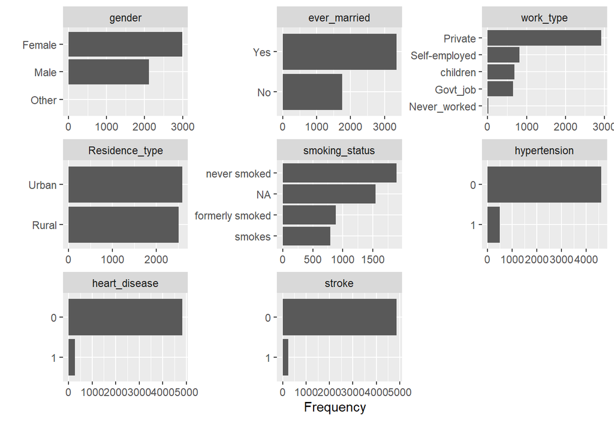

```r
#install.packages("DataExplorer")
library(DataExplorer)
#plot_str(df) plots the dataset structure
plot_str(dataset)
#plot_bar(df) plots the bar chart for each discrete feature
plot_bar(dataset)
```

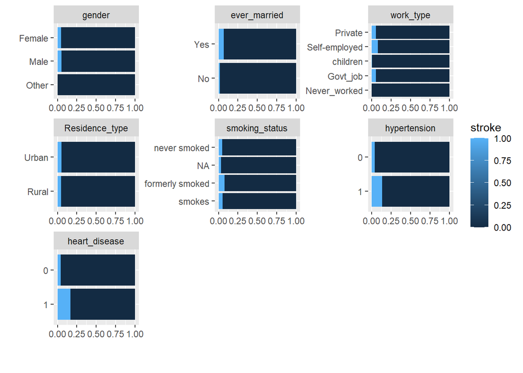

```r
#The charts can also be grouped by a discrete variable, e.g. the presence of a cardiovascular disease, by: plot_bar(df, by="cardio")
plot_bar(dataset, by="stroke")
```

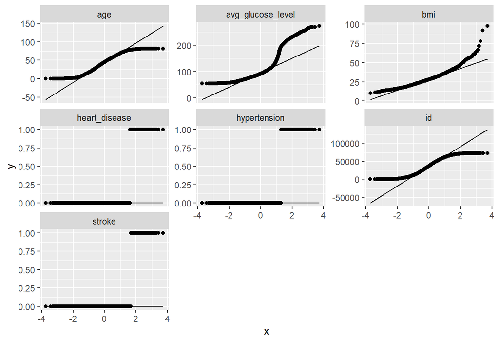

```r
#plot_qq(df) plots quantile-quantile for each continuous feature
plot_qq(dataset)
```

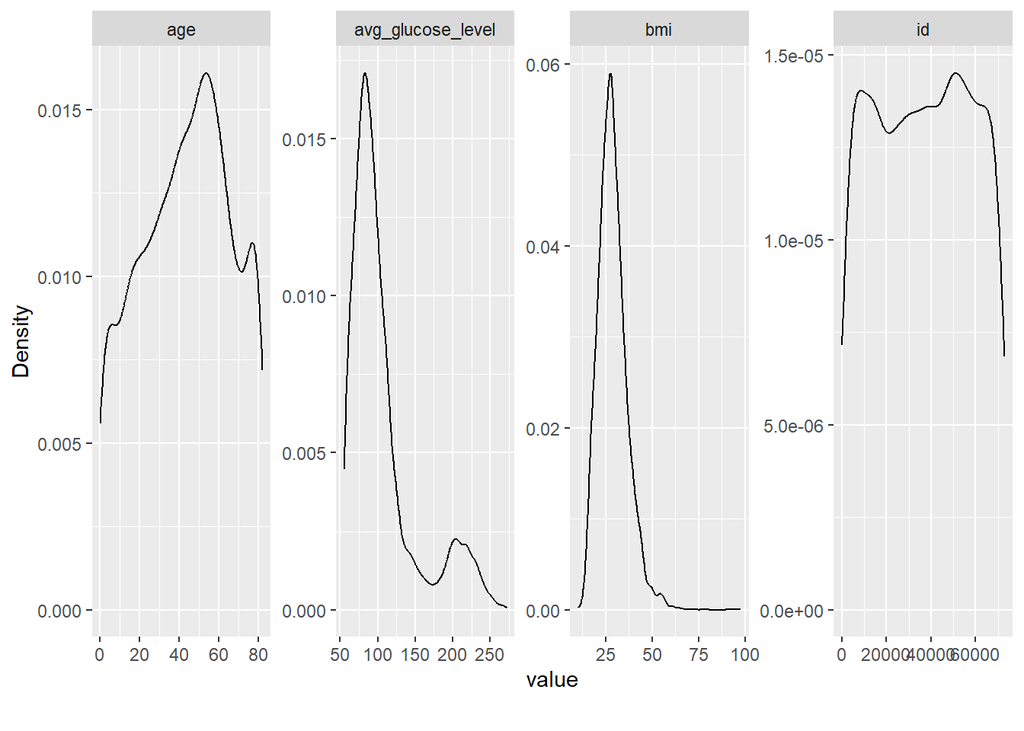

```r
#plot_density(df) plots density estimates for each continuous feature
plot_density(dataset)
```

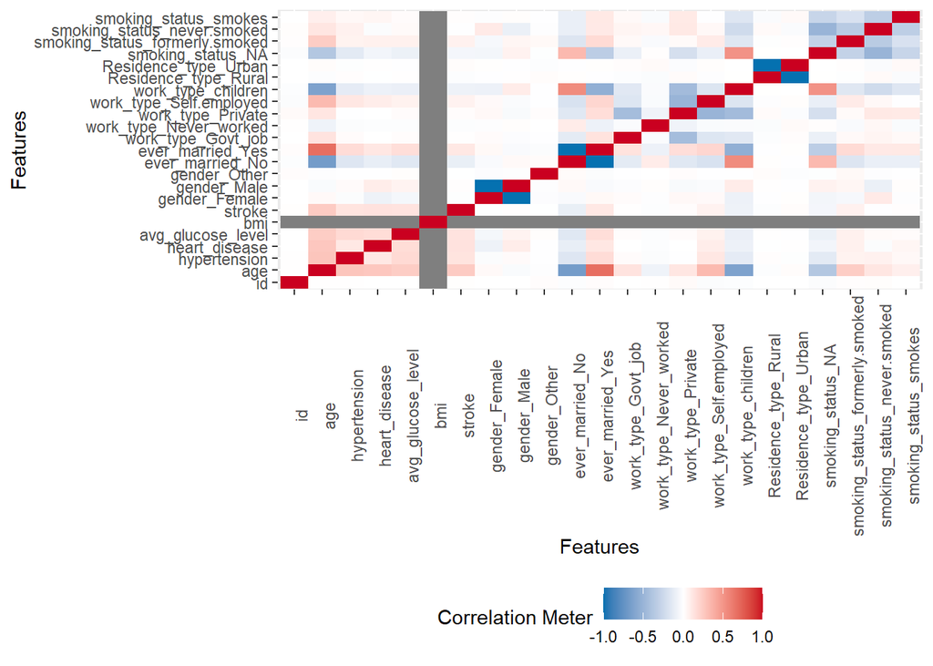

```r
#plot_correlation(df) to visualize correlation heatmap
plot_correlation(dataset)
```

```r
#plot_prcomp(df) performs Principal Component Analysis (PCA) and plots the percentage of variance explained by each principal component
#plot_prcomp(dataset)

#check the number of missing values for each column N/A<>NA =>all 0 in counting null
sapply(dataset,function(x) sum(is.na(x)))
```

```
##                id            gender               age      hypertension
##                 0                 0                 0                 0
##     heart_disease      ever_married         work_type    Residence_type
##                 0                 0                 0                 0
## avg_glucose_level               bmi    smoking_status            stroke
##                 0               201              1544                 0
```

```r
##Calculate the proportion of missingness for each variable
dataset %>%
  map(is.na) %>%
  map(sum)%>%
  map(~./nrow(dataset))%>%
  bind_cols()
```

```
## # A tibble: 1 × 12
##      id gender   age hypertension heart_disease ever_married work_type
##   <dbl>  <dbl> <dbl>        <dbl>         <dbl>        <dbl>     <dbl>
## 1     0      0     0            0             0            0         0
## # ℹ 5 more variables: Residence_type <dbl>, avg_glucose_level <dbl>, bmi <dbl>,
## #   smoking_status <dbl>, stroke <dbl>
```

```r
##Drop rows with NA values in column
dataset <- dataset %>%
  drop_na(bmi)
dataset <- dataset %>%
  drop_na(smoking_status)
dim(dataset)
```

```
## [1] 3426   12
```

```r
#check the number of missing values for each column N/A<>NA =>all 0 in counting null
sapply(dataset,function(x) sum(is.na(x)))
```

```
##                id            gender               age      hypertension
##                 0                 0                 0                 0
##     heart_disease      ever_married         work_type    Residence_type
##                 0                 0                 0                 0
## avg_glucose_level               bmi    smoking_status            stroke
##                 0                 0                 0                 0
```